# Homework 1

Elif Konyar - IE582 - Fall 2018

# Introduction

Homework 1 is an introduction to sports forecasting where we are asked to observe and analyze the behaviours of different betting companies and leagues with the use of information from the two data sets -data_matches and data_odds- (odds from different betting companies, scores of the matches etc.).

```r
data_matches <- readRDS("/Users/elifkonyar/Desktop/IE 582/HW1/df9b1196-e3cf-4cc7-9159-f236fe738215_matches.rds")
data_odds <- readRDS("/Users/elifkonyar/Desktop/IE 582/HW1/df9b1196-e3cf-4cc7-9159-f236fe738215_odd_details.rds")
```

## Task 1

The objective of this task is to understand if bookmakers perform well in setting their odds for over and under bets. For over/under bets, 2.5 is chosen as the threshold. This information can be found in “totalhandicap” column in the “data_odds” data set.

where prob_over can be calculated simply by 1/odd_over, and prob_under similarly.

The strategy in evaluating the performance of the bookmakers is as follows:

1. Determining a probability range (a)
2. Counting the games that finished over and that have the implied over probability in corresponding bin (b)
3. Counting the total number of games in the corresponding bin (c)
4. Calculating the estimated probability of overs ((b)/(c))
5. Calculating the implied over probability average in each bin.

In the whole homework, the bin range is taken as 0.05 making 20 bins in total. Generally, in these kind of analyses, the number of bins is decided according to the number of observations, and it is between n^1/2 and n/4 where n is the number of observations. However, in this case, due to the very low number of observations in the bins, it is decided to decrease the number of bins to make the analyses statistically significant. Moreover, the range is adjusted according to the minimum and the maximum implied over probabilities to eliminate the bins with zero observations. Additionally, the bins are modified such that each of them have more than 4 observations because otherwise the results would not be statistically significant again with very few observations in the bins.

After these calculations, the performance of the bookmakers will be tested by plotting the implied over probability average versus the estimated probability of overs. For a successful bookmaker, it would be expected to see the points around x=y line which would show the bookmaker is good at setting the “over” odds.

### Section A

In this part, 5 bookmakers that have over/under odds are selected, and their performances on both final and initial bets are evaluated. In the data, it can be seen that there are more than one bet for each match with the indicated timestamps because the odds may change due to injuries, team conditions, red-card penalties from previous matches, etc. In this task, the concentration will be on the initial over bets and final over bets.

With the following code, the selection for the bets are done. The over probabilities are calculated. However, the implied probabilities will be calculated in the coming parts.

```r
data_ou <- data_odds[oddtype == "over" | oddtype == "under"]
data_ou <- data_ou[totalhandicap == 2.5]
data_ou$prob <- 1/(data_ou$odd)  #calculating over probabilities
data_overs <- data_ou[oddtype == "over"]
data_unders <- data_ou[oddtype == "under"]
```

For this task, 5 bookmakers are selected such that they have the highest number of over bets for the matches.

```r
bookmaker_list <- data_overs[, .N, by = .(bookmaker)]
bookmaker_list <- bookmaker_list[order(-N)]
bookmaker_set <- bookmaker_list[1:5, 1:2]
bookmaker_set
```

```
##    bookmaker     N
## 1:     10Bet 12740
## 2:   Betsson  6987
## 3:   Betsafe  6762
## 4:    bet365  6640
## 5:  Pinnacle  6612
```

```r
selected_bookmakers1 <- data_overs[bookmaker == bookmaker_set[1,
    1]]  #10Bet
selected_bookmakers2 <- data_overs[bookmaker == bookmaker_set[2,
    1]]  #Betsson
selected_bookmakers3 <- data_overs[bookmaker == bookmaker_set[3,
    1]]  #Betsafe
selected_bookmakers4 <- data_overs[bookmaker == bookmaker_set[4,
    1]]  #bet365
selected_bookmakers5 <- data_overs[bookmaker == bookmaker_set[5,
    1]]  #Pinnacle
bm1_under <- data_unders[bookmaker == bookmaker_set[1, 1]]  #10Bet
bm2_under <- data_unders[bookmaker == bookmaker_set[2, 1]]  #Betsson
bm3_under <- data_unders[bookmaker == bookmaker_set[3, 1]]  #Betsafe
bm4_under <- data_unders[bookmaker == bookmaker_set[4, 1]]  #bet365
bm5_under <- data_unders[bookmaker == bookmaker_set[5, 1]]  #Pinnacle
```

#### Bookmaker 1 (10Bet)

##### Performance on Final Probabilities

Firstly, the performance of 10Bet on final odds will be evaluated. Therefore, the odds with the highest timestamps are chosen.

```r
selected_bookmakers1_final <- selected_bookmakers1[, .SD[which.max(date)],
    by = matchId]
bm1_under_final <- bm1_under[, .SD[which.max(date)], by = matchId]
```

The final implied over probabilities of 10Bet are calculated with the formula stated in the Task 1 part.

```r
under_prob <- bm1_under_final[, `:=`(under_prob, prob)]
under_prob <- under_prob[, .(matchId, under_prob)]
selected_bookmakers1_final <- left_join(selected_bookmakers1_final,
    under_prob, by = c(matchId = "matchId"))
# calculating implying probabilities
selected_bookmakers1_final$implied <- (selected_bookmakers1_final$prob)/(selected_bookmakers1_final$prob +
    selected_bookmakers1_final$under_prob)
```

Afterwards, by using the score information from “data_matches” dataset, whether a match is finished over or not is determined. As mentioned earlier, 2.5 goals is selected as threshold while specifying the the over condition of the matches. A new “is_over” column is added as the indicator after comparing the total number of goals with 2.5. In the data, there are also matches which have not been played yet. These matches are omitted since the over or under information is not available.

```r
score_info <- data_matches[, .(matchId, score)]
# combining the score information of the matches with the
# odds and probabilities
selected_bookmakers1_final <- left_join(selected_bookmakers1_final,
    score_info, by = c(matchId = "matchId"))
# omitting not-finished matches
selected_bookmakers1_final <- na.omit(selected_bookmakers1_final,
    cols = "score", invert = FALSE)
# adjusting the score column
selected_bookmakers1_final <- selected_bookmakers1_final %>%
    separate(score, c("home_goals", "away_goals"), ":")
selected_bookmakers1_final$home_goals <- as.numeric(selected_bookmakers1_final$home_goals)
selected_bookmakers1_final$away_goals <- as.numeric(selected_bookmakers1_final$away_goals)
selected_bookmakers1_final$total_goals <- selected_bookmakers1_final$home_goals +
    selected_bookmakers1_final$away_goals
# making comparison and adding 'is_over column'
selected_bookmakers1_final <- as.data.frame(selected_bookmakers1_final)
selected_bookmakers1_final[, "is_over"] <- lapply(selected_bookmakers1_final,
    FUN = function(x) ifelse(selected_bookmakers1_final$total_goals >
        2.5, 1, 0))
```

After this step, the probability range is determined. As the first step in specifying the bins, the minimum and the maximum of the implied over probabilities are checked. As it can be seen below, the minimum implied probability is 0.2812, and the maximum is 0.7857. Therefore, the range will be (0.25,0.30],(0.30,0.35],…,(0.75,0.80] with the number of 11 bins in total.

The “count” array keeps the total number of matches, the “avg” array keeps the sum of the implied over probabilities and the “num_over” array keeps the number of matches that finished over in the corresponding bin.

```r
# checking the minimum and the maximum
summary(selected_bookmakers1_final$implied)
```

```
##    Min. 1st Qu.  Median    Mean 3rd Qu.    Max.
##  0.2812  0.4599  0.5053  0.5119  0.5591  0.7857
```

```r
# creating bins
range_over <- 0.25
for (i in 6:16) {
    range_over <- c(range_over, i/20)
}
count <- array(0, 11)
avg <- array(0, 11)
num_over <- array(0, 11)

for (j in 1:nrow(selected_bookmakers1_final)) {
    for (k in 1:11) {
        if (selected_bookmakers1_final[j, 10] > range_over[k] &
            selected_bookmakers1_final[j, 10] <= range_over[k +
                1]) {
            count[k] <- count[k] + 1
            avg[k] <- avg[k] + selected_bookmakers1_final[j,
                10]
            if (selected_bookmakers1_final[j, 14] == 1) {
                num_over[k] <- num_over[k] + 1
            }
            break
        }
    }
}
# checking the number of observations in each bin
count
```

```
##  [1]   1  18 105 447 758 690 464 201  90  27   7
```

Here, the number of observations in count arrays are checked in order the results to be meaningful. As it can be seen above, the first element in the count array do not have enough observations. Therefore, the first and the second bins are merged. There is no need to do any further merges. The new probability range is (0.25,0.35],(0.35,0.40],…,(0.75,0.80].

```r
count[2] <- count[2] + count[1]
avg[2] <- avg[2] + avg[1]
num_over[2] <- num_over[2] + num_over[1]
count <- count[2:11]
avg <- avg[2:11]
num_over <- num_over[2:11]
```

As the final step before plotting, the fraction of games finished over for the corresponding bin and the implied “over” probability average in bins are calculated.

```r
for (k in 1:length(count)) {
    avg[k] <- avg[k]/count[k]
    num_over[k] <- num_over[k]/count[k]
}
```

Finally, the scatter plot of final implied over probability average versus the estimated probabilities of overs is shown below:

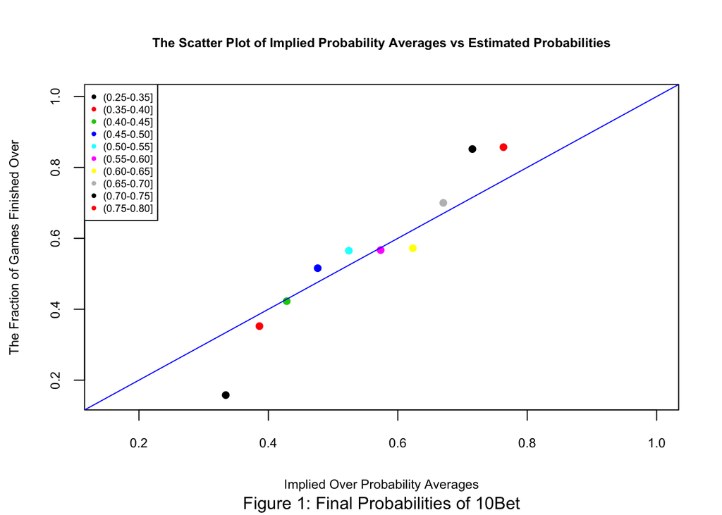

```r
color <- seq(1, length(count))
plot(avg, num_over, col = color, xlim = c(0.15, 1), ylim = c(0.15,
    1), lwd = 2, pch = 16, xlab = "Implied Over Probability Averages",
    ylab = "The Fraction of Games Finished Over", main = "The Scatter Plot of Implied Probability Averages vs Estimated Probabilities",
    cex.main = 0.75, cex.lab = 0.75, cex.axis = 0.75, sub = "Figure 1: Final Probabilities of 10Bet")
legend("topleft", c("(0.25-0.35]", "(0.35-0.40]", "(0.40-0.45]",
    "(0.45-0.50]", "(0.50-0.55]", "(0.55-0.60]", "(0.60-0.65]",
    "(0.65-0.70]", "(0.70-0.75]", "(0.75-0.80]"), col = color,
    cex = 0.6, pch = 16)
abline(0, 1, col = 100)
```

As it can be seen from the scatter plot, the points in the inside part are considerably on the x=y line which indicates that this bookmaker is good at setting odds for over bets. However, there are some deviations from the line in the first bin and the last two bins. When the count array is checked, it can be seen that they have relatively small number of observations compared to the inside bins. Therefore, the conclusion from the inside bins are more statistically significant. Also, it may be due to the bookmaker’s desire to make money. When the probability of the match finishing over is very low, the odd would be very high. However, the bookmaker may adjust this high odd by diminishing slightly; so that, people assume that team is not that low likely to win the match. Hence, the implied over probability average is higher than the estimated probability for the (0.25,0.35] bin.

##### Performance on Initial Probabilities

The same procedure is applied while evaluating the performance of 10Bet on initial probabilities. However, while implied probabilities are being calculated, the initial over and under probabilities are determined by considering the bet with the lowest timestamp for each match.

```r
# determining the initial over and under probabilities
selected_bookmakers1_ini <- selected_bookmakers1[, .SD[which.min(date)],
    by = matchId]
bm1_under_ini <- bm1_under[, .SD[which.min(date)], by = matchId]
under_prob_ini <- bm1_under_ini[, `:=`(under_prob, prob)]
under_prob_ini <- under_prob_ini[, .(matchId, under_prob)]
selected_bookmakers1_ini <- left_join(selected_bookmakers1_ini,
    under_prob_ini, by = c(matchId = "matchId"))
# calculating implying probabilities
selected_bookmakers1_ini$implied <- (selected_bookmakers1_ini$prob)/(selected_bookmakers1_ini$prob +
    selected_bookmakers1_ini$under_prob)
# combining the score information of the matches with the
# odds and probabilities
selected_bookmakers1_ini <- left_join(selected_bookmakers1_ini,
    score_info, by = c(matchId = "matchId"))
# omitting not-finished matches
selected_bookmakers1_ini <- na.omit(selected_bookmakers1_ini,
    cols = "score", invert = FALSE)
# adjusting the score column
selected_bookmakers1_ini <- selected_bookmakers1_ini %>% separate(score,
    c("home_goals", "away_goals"), ":")
selected_bookmakers1_ini$home_goals <- as.numeric(selected_bookmakers1_ini$home_goals)
selected_bookmakers1_ini$away_goals <- as.numeric(selected_bookmakers1_ini$away_goals)
selected_bookmakers1_ini$total_goals <- selected_bookmakers1_ini$home_goals +
    selected_bookmakers1_ini$away_goals
# making comparison and adding 'is_over column'
selected_bookmakers1_ini <- as.data.frame(selected_bookmakers1_ini)
selected_bookmakers1_ini[, "is_over"] <- lapply(selected_bookmakers1_ini,
    FUN = function(x) ifelse(selected_bookmakers1_ini$total_goals >
        2.5, 1, 0))
```

After the initial steps, the probability range is determined. As the first step in specifying the bins, the minimum and the maximum of the implied over probabilities are checked. As it can be seen below, the minimum implied probability is 0.3580, and the maximum is 0.7807. Therefore, the range will be (0.35,0.40],(0.40,0.45],…,(0.75,0.80] with the number of 9 bins in total.

```r
# checking the minimum and the maximum
summary(selected_bookmakers1_ini$implied)
```

```
##    Min. 1st Qu.  Median    Mean 3rd Qu.    Max.
##  0.3580  0.4701  0.5053  0.5123  0.5521  0.7807
```

```r
# creating bins
range_over_ini <- 0.35
for (i in 8:16) {
    range_over_ini <- c(range_over_ini, i/20)
}

count_ini <- array(0, 9)
avg_ini <- array(0, 9)
num_over_ini <- array(0, 9)
selected_bookmakers1_ini <- as.data.frame(selected_bookmakers1_ini)

for (j in 1:nrow(selected_bookmakers1_ini)) {
    for (k in 1:9) {
        if (selected_bookmakers1_ini[j, 10] > range_over_ini[k] &
            selected_bookmakers1_ini[j, 10] < range_over_ini[k +
                1]) {
            count_ini[k] <- count_ini[k] + 1
            avg_ini[k] <- avg_ini[k] + selected_bookmakers1_ini[j,
                10]
            if (selected_bookmakers1_ini[j, 14] == 1) {
                num_over_ini[k] <- num_over_ini[k] + 1
            }
            break
        }
    }
}
# checking the number of observations in each bin
count_ini
```

```
## [1]  75 343 852 732 455 194  63  15   1
```

Here, the number of observations in count_ini array is checked in order the results to be meaningful. As it can be seen above, the last element in the count_ini array does not have enough observations. Therefore, last two bins are merged. There is no need to do any further merges. The new probability range is (0.35,0.40],(0.40,0.45],…,(0.70,0.80].

```r
count_ini[8] <- count_ini[8] + count_ini[9]
avg_ini[8] <- avg_ini[8] + avg_ini[9]
num_over_ini[8] <- num_over_ini[8] + num_over_ini[9]
count_ini <- count_ini[1:8]
avg_ini <- avg_ini[1:8]
num_over_ini <- num_over_ini[1:8]
```

As the final step before plotting, the fraction of games finished over for the corresponding bin and the implied “over” probability average in bins are calculated.

```r
for (k in 1:length(count_ini)) {
    avg_ini[k] <- avg_ini[k]/count_ini[k]
    num_over_ini[k] <- num_over_ini[k]/count_ini[k]
}
```

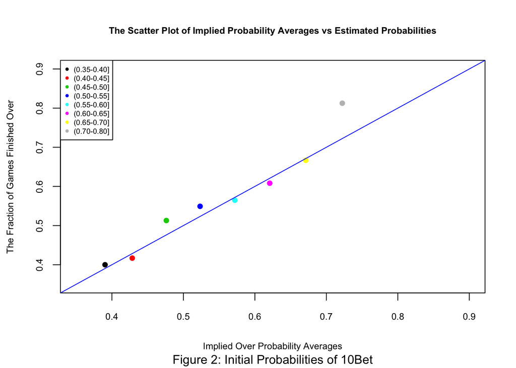

```r
color <- seq(1, length(count_ini))
plot(avg_ini, num_over_ini, col = color, xlim = c(0.35, 0.9),
    ylim = c(0.35, 0.9), lwd = 2, pch = 16, xlab = "Implied Over Probability Averages",
    ylab = "The Fraction of Games Finished Over", main = "The Scatter Plot of Implied Probability Averages vs Estimated Probabilities",
    cex.main = 0.75, cex.lab = 0.75, cex.axis = 0.75, sub = "Figure 2: Initial Probabilities of 10Bet")
legend("topleft", c("(0.35-0.40]", "(0.40-0.45]", "(0.45-0.50]",
    "(0.50-0.55]", "(0.55-0.60]", "(0.60-0.65]", "(0.65-0.70]",
    "(0.70-0.80]"), col = color, cex = 0.6, pch = 16)
abline(0, 1, col = 100)
```

As it can be seen from the scatter plot, the points corresponding to the bins except the last one reside on the x=y line which indicates that this bookmaker is good at setting the initial odds for over bets. When compared with the final odds plot, it can be seen that the performance is better. This may be due to the fact that the bookmaker reacts to the changes in the match and the player conditions too much even though it is not necessary. Additionally, in the plot, the last point corresponding to the (0.70-0.8] bin deviates from the x=y line. One reason can be the low number of observations which brings the statistical significance issue to the table similar to the previous case. Another reason can be that the bookmaker may want to increase the number of people betting on the matches with high over probabilities also; so that, the bookmaker increases the odds a little because there is also chance of the match finishing under even though it is less probable.

#### Bookmaker 2 (Betsson)

##### Performance on Final Probabilities

The same procedure with 10Bet is applied while evaluating the performance of Betsson on final probabilities. The bins are adjusted according to the number of observations with the similar strategy of the 10Bet. In this case, the minimum implied probability is 0.3234, and the maximum is 0.7935. Therefore, the range will be (0.30,0.35],(0.35,0.40],…,(0.75,0.80] with the number of 10 bins in total before merging. Since all the bins have more than 4 observations, there is no need to perform any mergings.

The summary of implied probabilities:

```
##    Min. 1st Qu.  Median    Mean 3rd Qu.    Max.
##  0.3234  0.4599  0.5107  0.5147  0.5640  0.7935
```

The number of observations in bins:

```
##  [1]  12 106 460 790 666 459 230 110  34   5
```

The scatter plot of final implied over probability average versus the estimated probabilities of overs is shown below:

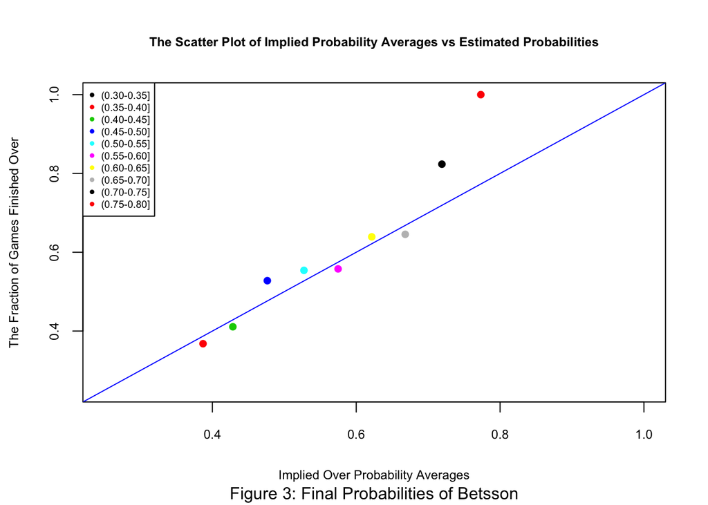

As it can be seen from the scatter plot above, the inside bins reside on the x=y line which supports that the Betsson is good at setting the over odds. However, the points corresponding to the bins on the boundary deviate from the x=y line. It may be again due to the small number of observations in those bins. Moreover, it can be due to the desire of the bookmaker on increasing the number of people betting on those matches similar to the previous case because the implied over probabilities are less than the fraction of games finished over which indicates the higher odds.

##### Performance on Initial Probabilities

The same procedure is applied while evaluating the performance of Betsson on initial probabilities. In this case, the minimum implied probability is 0.3412, and the maximum is 0.7741. Therefore, the range will be (0.30,0.35],(0.35,0.40],…,(0.75,0.80] with the number of 10 bins in total before mergings. Since the first and the last elements in the count array do not have enough observations, the first two and the last two bins are merged. The new probability range is (0.30,0.40],(0.40,0.45],…,(0.70,0.80].

The summary of implied probabilities:

```
##    Min. 1st Qu.  Median    Mean 3rd Qu.    Max.
##  0.3412  0.4652  0.5106  0.5133  0.5558  0.7741
```

The number of observations in each bin:

```
##  [1]   1  79 402 774 695 455 230  74  21   1
```

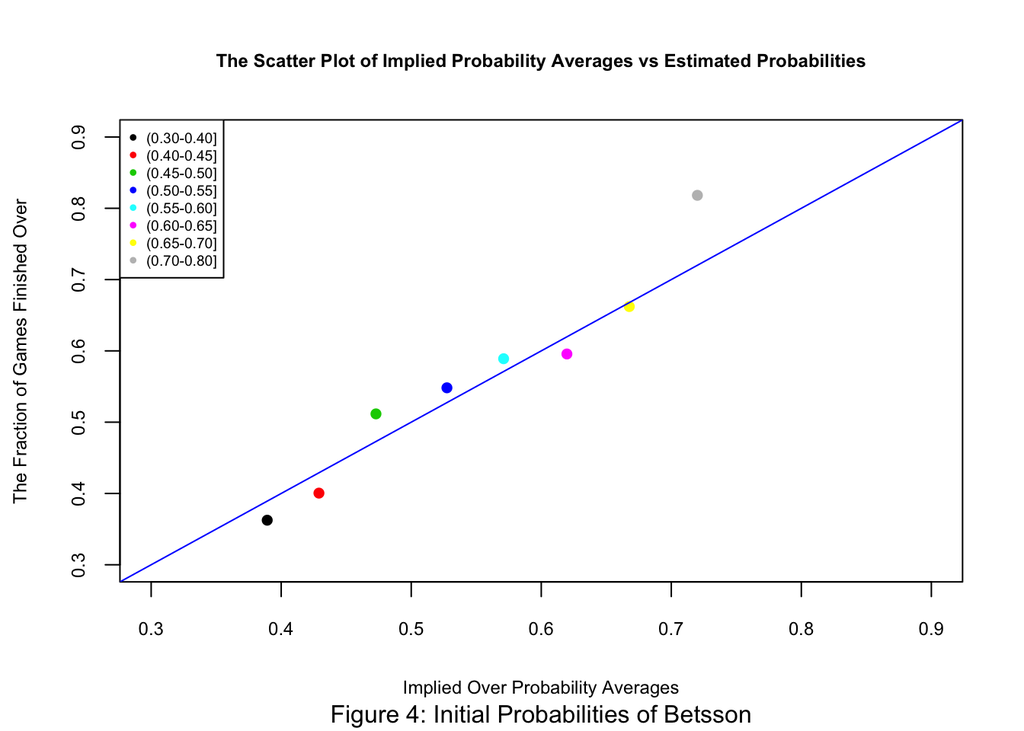

As it can be seen from the scatter plot, the points corresponding to the bins except the last one reside on the x=y line which indicates that this bookmaker Betsson is good at setting the initial odds for over bets. When compared with the final odds plot, it can be seen that the performance is better. The points reside on the line more, and the performance on the boundary bins is also better. This may be due to the similar reason with Bet10 which is that the bookmaker reacts to the changes in the match and the player conditions too much even though it is not necessary. In addition, in the plot, the last point corresponding to the (0.70-0.8] bin deviates from the x=y line. Similar to the previous case, it can be due to the low number of observations or the bookmaker’s increasing the odd intentionally.

#### Bookmaker 3 (Betsafe)

##### Performance on Final Probabilities

The same procedure is applied while evaluating the performance of Betsafe on final probabilities. In this case, the minimum implied probability is 0.3234, and the maximum is 0.7935. Therefore, the range will be (0.30,0.35],(0.35,0.40],…,(0.75,0.80] with the number of 10 bins in total at first.

The summary of implied probabilities:

```
##    Min. 1st Qu.  Median    Mean 3rd Qu.    Max.
##  0.3234  0.4603  0.5080  0.5148  0.5636  0.7935
```

As it can be seen below, all the bins in count array have more than 4 observations. Therefore, there is no need to do any mergings.

```
##  [1]  12 101 475 758 689 467 226 104  34   6
```

As the final step, the scatter plot of final implied over probability average versus the estimated probabilities of overs is shown below:

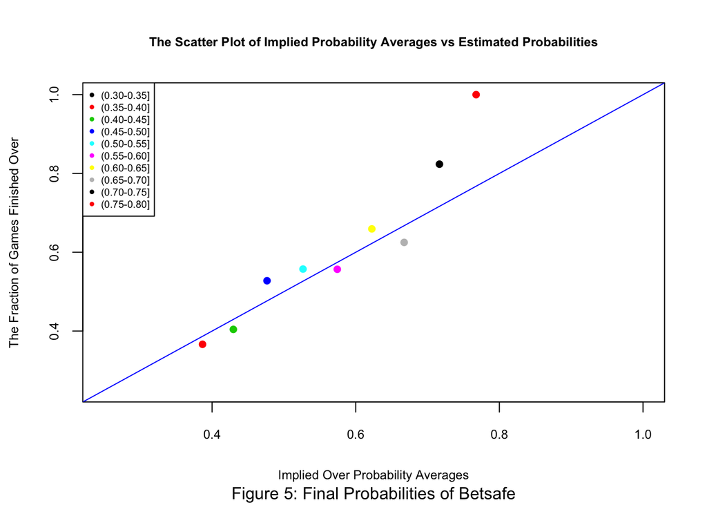

Similar to the previous cases, the inside bins reside on the x=y line which supports that the Betsafe is good at setting the over odds. However, the points corresponding to the bins on the boundary deviate from the x=y line. It may be again due to the small number of observations in those bins.

##### Performance on Initial Probabilities

The same procedure is applied while evaluating the performance of Betsafe on initial probabilities. In this case, the minimum implied probability is 0.3412, and the maximum is 0.7741. Therefore, the range will be (0.30,0.35],(0.35,0.40],…,(0.75,0.80] with the number of 10 bins in total.

The summary of the implied probabilities:

```
##    Min. 1st Qu.  Median    Mean 3rd Qu.    Max.
##  0.3412  0.4649  0.5080  0.5138  0.5558  0.7741
```

As it can be seen below, the first and the last elements in the count array do not have enough observations. Therefore, the first two and the last two bins are merged. There is no need to do any further merges. The new probability range is (0.30,0.40],(0.40,0.45],…,(0.70,0.80].

```
##  [1]   1  78 448 746 697 493 229  69  20   1
```

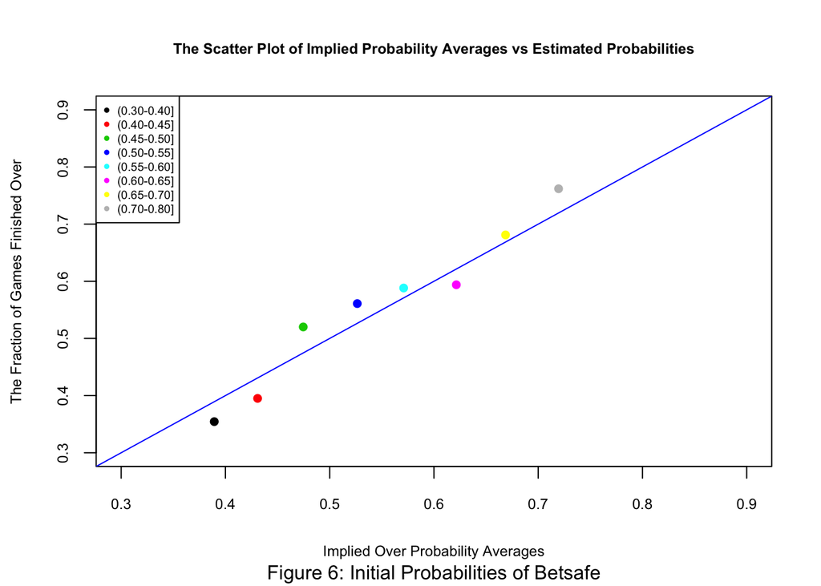

As it can be seen from the scatter plot, the points reside on the x=y line which indicates that this bookmaker Betsafe is really good at setting the initial odds for over bets. When compared with the final odds plot, it can be seen that the performance is much better. This may be due to the similar reason with Bet10 and Betsson which is that the bookmaker reacts to the changes in the match and the player conditions too much even though it is not necessary.

#### Bookmaker 4 (Bet365)

##### Performance on Final Probabilities

The same procedure is applied while evaluating the performance of Bet365 on final probabilities. In this part, the minimum implied probability is 0.3049, and the maximum is 0.7830. Therefore, the range will be (0.30,0.35],(0.35,0.40],…,(0.75,0.80] with the number of 10 bins in total.

The summary of the implied probabilities:

```
##    Min. 1st Qu.  Median    Mean 3rd Qu.    Max.
##  0.3049  0.4605  0.5132  0.5133  0.5628  0.7830
```

As it can be seen from the count array below, all the bins in the count array have more than 4 observations. Therefore, there is no need to do any mergings.

```
##  [1]  16  86 508 765 639 539 160 123  30   6
```

Finally, the scatter plot of final implied over probability average versus the estimated probabilities of overs is shown below:

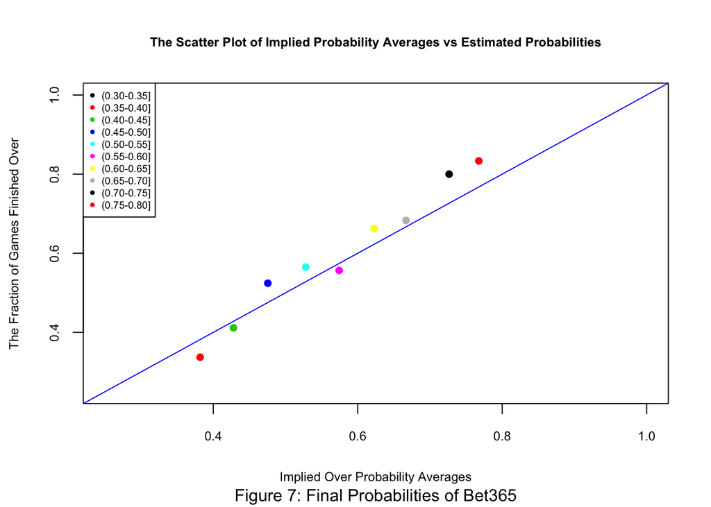

In Bet365 case, all the bins almost reside on the x=y line which supports that the Bet365 is good at setting the over odds. When compared with the previous bookmakers’ performances on the final odds, it can be seen from the scatterplots that Bet365 is performing better. Although there are very slight deviations on boundaries, they may be due to the lower number of observations compared to the inside bins.

##### Performance on Initial Probabilities

The same procedure is applied while evaluating the performance of Bet365 on initial probabilities. For the initial probabilities, the minimum implied probability is 0.3612, and the maximum is 0.7844. Therefore, the range will be (0.35,0.40],(0.40,0.45],…,(0.75,0.80] with the number of 9 bins in total.

The summary of the implied probabilities:

```
##    Min. 1st Qu.  Median    Mean 3rd Qu.    Max.
##  0.3612  0.4737  0.5132  0.5132  0.5526  0.7844
```

As it can be seen below, the last element in the count array does not have enough observations. Therefore, the last two bins are merged. There is no need to do any further merges. The new probability range is (0.35,0.40],(0.40,0.45],…,(0.70,0.80].

```
## [1]  25 414 787 776 508 160  66  12   1
```

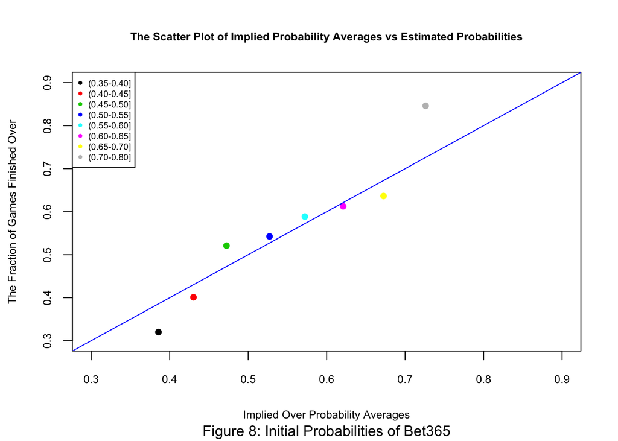

As it can be seen from the scatter plot, the points reside on the x=y line except the one from the last bin on the boundary which indicates that this bookmaker Bet365 is not bad at setting the initial odds for over bets. The deviation on the boundary may again be due to the low number of observation in the bin. When compared with the final odds plot, it can be seen that the performance is a little worse here. This implies that the bookmaker is good at reacting to the changes in team conditions, injuries etc.

#### Bookmaker 5 (Pinnacle)

##### Performance on Final Probabilities

The same procedure is applied while evaluating the performance of Pinnacle on final probabilities. In this case, the minimum implied probability is 0.3161, and the maximum is 0.6787. Therefore, the range will be (0.30,0.35],(0.35,0.40],…,(0.65,0.70] with the number of 8 bins in total.

The summary of the implied probabilities:

```
##    Min. 1st Qu.  Median    Mean 3rd Qu.    Max.
##  0.3161  0.4594  0.5051  0.5086  0.5570  0.6787
```

It can be seen from the count array that all the bins have more than 4 observations. Thus, there is no need to do any mergings.

```
## [1]  17 128 407 746 671 459 245  47
```

Finally, the scatter plot of final implied over probability average versus the estimated probabilities of overs is shown below:

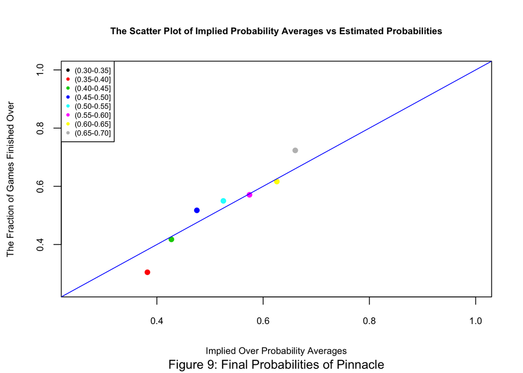

As it can be seen from the scatterplot, the deviations on the boundary is not too much as in the cases of Bet10, Betssafe and Bet365. The points from the inside points reside on the x=y line. The performance of this bookmaker can be said to be better than the first three bookmakers on the final odds.

##### Performance on Initial Probabilities

The same procedure is applied while evaluating the performance of Pinnacle on initial probabilities. In this case, the minimum implied probability is 0.3357, and the maximum is 0.6667. Therefore, the range will be (0.30,0.35],(0.35,0.40],…,(0.65,0.70] with the number of 8 bins in total.

The summary of the implied probabilities:

```
##    Min. 1st Qu.  Median    Mean 3rd Qu.    Max.
##  0.3357  0.4656  0.5051  0.5080  0.5494  0.6667
```

As it can be seen below, the first element in the count array does not have enough observations. Therefore, the first two bins are merged. There is no need to do any further merges. The new probability range is (0.30,0.40],(0.40,0.45],…,(0.65,0.70].

```
## [1]   2  78 405 755 756 439 215  10
```

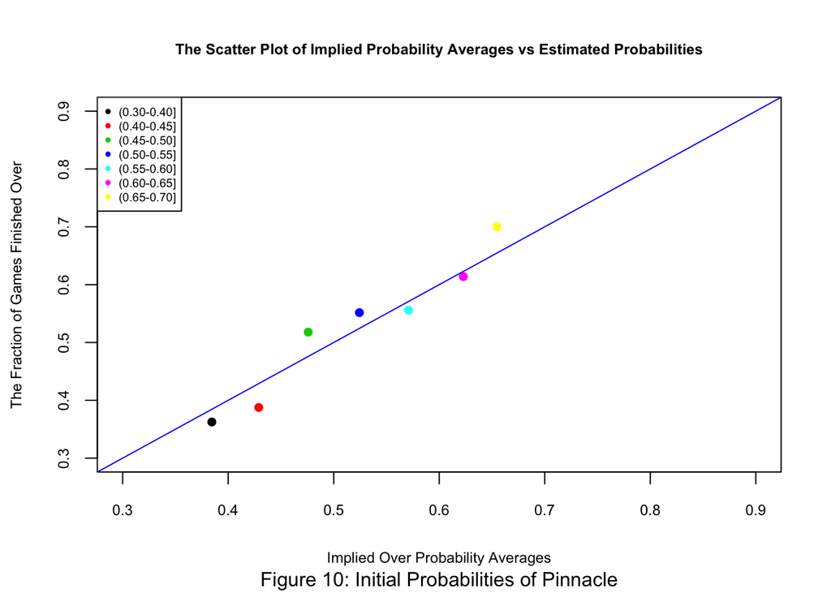

This bookmaker’s performance on initial odds is better compared to his/her performance on the final odds. The points are very close to the x=y line.

When all the 5 bookmakers are compared, it can be seen that, the third bookmaker (Betsafe) is performing the best on setting the initial odds, wherease the fourth bookmaker’s (bet365) performance on setting the final odds is the best.

### Section B

In this section, the objective is to evaluate if a bookmaker is consistently good at determining “over” probabilities. Therefore, the task is to repeat the analysis of Section A for each year from 2010 to 2018. “bet365” is chosen for this task since their performance on the final odds is concluded to be the best among 5 bookmakers.

The first task is to divide the match instances into the subset of the corresponding year:

```r
selected_bookmakers4_final$time <- as.POSIXct(as.numeric(selected_bookmakers4_final$date),
    origin = "1970-01-01", tz = "GMT")
selected_bookmakers4_final <- selected_bookmakers4_final %>%
    separate(time, c("year", "rest"), "-")
selected_bookmakers4_final <- as.data.table(selected_bookmakers4_final)
selected_bookmakers4_final <- selected_bookmakers4_final[, -16,
    with = FALSE]
years <- selected_bookmakers4_final[, .N, keyby = year]
summary(selected_bookmakers4_final$implied)
```

[output not shown]

Here, it can be seen that the minimum implied over probability is 0.3049, and the maximum is 0.7830. Therefore, the range for the years is (0.30,0.35],(0.35,0.40],…,(0.75,0.80] with the number of 10 bins in total.

```r
range_over_time <- 0.3
for (i in 7:16) {
    range_over_time <- c(range_over_time, i/20)
}

# creating the matrices over time for interested statistics
years <- as.data.frame(years)
count_time = matrix(rep(c(0), each = 10 * 9), nrow = 10, ncol = 9)
colnames(count_time) <- years[, 1]
avg_time = matrix(rep(c(0), each = 10 * 9), nrow = 10, ncol = 9)
colnames(avg_time) <- years[, 1]
num_over_time = matrix(rep(c(0), each = 10 * 9), nrow = 10, ncol = 9)
colnames(num_over_time) <- years[, 1]
```

```r
selected_bookmakers4_final <- as.data.frame(selected_bookmakers4_final)

for (j in 1:nrow(selected_bookmakers4_final)) {
    for (k in 1:10) {
        if (selected_bookmakers4_final[j, 10] > range_over_time[k] &
            selected_bookmakers4_final[j, 10] < range_over_time[k +
                1]) {
            year <- selected_bookmakers4_final[j, 15]
            count_time[k, year] <- count_time[k, year] + 1
            avg_time[k, year] <- avg_time[k, year] + selected_bookmakers4_final[j,
                8]
            if (selected_bookmakers4_final[j, 14] == 1) {
                num_over_time[k, year] <- num_over_time[k, year] +
                  1
            }
            break
        }
    }
}
```

Here, the number of observations in count_time matrix should be checked in order the results to be statistically significant.

```r
count_time
```

```
##       2010 2011 2012 2013 2014 2015 2016 2017 2018
##  [1,]    0    0    0    1    0    2    0    9    4
##  [2,]    0    1    2    4   15   12   19   19   14
##  [3,]    1   69   39   40   50   87   86   84   52
##  [4,]    0  109   93   80   96  110   82   69   17
##  [5,]    0   90  108  104   92   80   79   51   35
##  [6,]    0   62   96   84   70   56   62   69   40
##  [7,]    0   13   21   28   27   11   17   30   13
##  [8,]    0   14   14   14   11   10   11   29   20
##  [9,]    0    1    5    1    7    1    1   10    4
## [10,]    0    0    0    0    1    0    0    3    2
```

So that each bin will have more than 4 observations. The other mergings for the remaining years are perfomed in a similar manner.

```r
# mergings: 2011
count_time[3, 2] <- count_time[2, 2] + count_time[3, 2]
count_time[2, 2] <- 0
avg_time[3, 2] <- avg_time[2, 2] + avg_time[3, 2]
avg_time[2, 2] <- 0
num_over_time[3, 2] <- num_over_time[2, 2] + num_over_time[3,
    2]
num_over_time[2, 2] <- 0

count_time[8, 2] <- count_time[8, 2] + count_time[9, 2]
count_time[9, 2] <- 0
avg_time[8, 2] <- avg_time[8, 2] + avg_time[9, 2]
avg_time[9, 2] <- 0
num_over_time[8, 2] <- num_over_time[8, 2] + num_over_time[9,
    2]
num_over_time[9, 2] <- 0
```

As the final step before plotting, the fraction of games finished over for the corresponding bin and the implied “over” probability average in bins are calculated.

```r
for (k in 1:10) {
    for (m in 1:9) {
        avg_time[k, m] <- avg_time[k, m]/count_time[k, m]
        num_over_time[k, m] <- num_over_time[k, m]/count_time[k,
            m]
    }
}
```

In the plotting part, the objective is to evaluate the performance of bet365 over the years. Therefore, the fraction of over games and the implied probability averages for each bin over the years are plotted. However, bins are divided into 3 groups for plotting due to the messy view when all the bins are on the same plot. Therefore, the first plot includes the bins within 0.30-0.45, the second plot includes the bins within 0.45-0.60 and the third plot have the bins within 0.60-0.75. When the bins are merged, no observation have been left in the 0.75-0.80 bin; so that it is not included in the plots.

In the plots, the x axis shows the years and there are two y axes: one for the fraction of the games finished over and the other for implied probability averages. Also, there are two lines for each bin: the one with the circles corresponds to the fraction of the games finished over and the one with the squares corresponds to the implied probability averages. The plots are in the following:

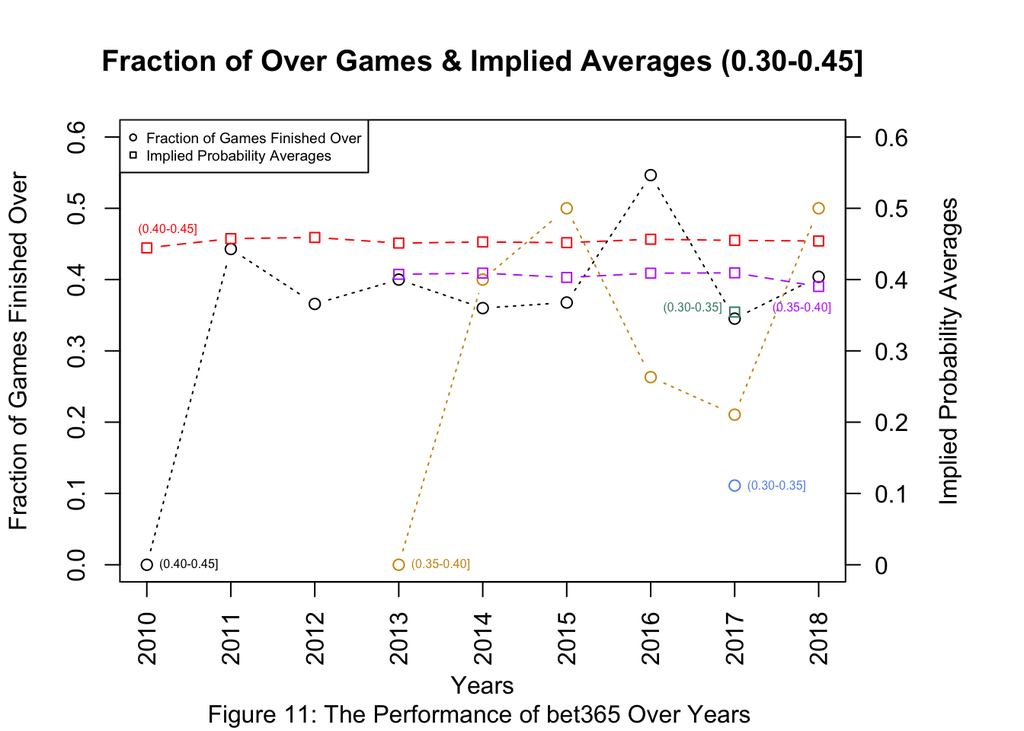

```r
# 0.30-0.45
xaxis <- c("2010", "2011", "2012", "2013", "2014", "2015", "2016",
    "2017", "2018")
par(mar = c(5, 4, 4, 6) + 0.1)
plot.ts(num_over_time[3, ], xaxt = "n", xlab = "", ylim = c(0,
    0.6), ylab = "Fraction of Games Finished Over", type = "b",
    pch = 21, col = "black", lty = 3, main = "Fraction of Over Games & Implied Averages (0.30-0.45]",
    sub = "Figure 11: The Performance of bet365 Over Years ")
axis(1, at = 1:9, labels = xaxis, las = 2)
axis(4, at = seq(0, 1, by = 0.1), col.axis = "black", las = 2,
    cex.axis = 1, labels = seq(0, 1, by = 0.1))
mtext("Years", side = 1, line = 3, cex.lab = 1, las = 1, col = "black")
mtext("Implied Probability Averages", side = 4, line = 3, cex.lab = 1,
    las = 0, col = "black")
text(1.5, 0, "(0.40-0.45]", cex = 0.5, col = "black")

lines(avg_time[3, ], type = "b", pch = 22, col = "red", lty = 2)
text(1.25, 0.47, "(0.40-0.45]", cex = 0.5, col = "red")

lines(num_over_time[1, ], type = "b", pch = 21, col = "cornflowerblue",
    lty = 3)
text(8.5, 0.11, "(0.30-0.35]", cex = 0.5, col = "cornflowerblue")

lines(avg_time[1, ], type = "b", pch = 22, col = "aquamarine4",
    lty = 2)
text(7.5, 0.36, "(0.30-0.35]", cex = 0.5, col = "aquamarine4")

lines(num_over_time[2, ], type = "b", pch = 21, col = "darkgoldenrod3",
    lty = 3)
text(4.5, 0, "(0.35-0.40]", cex = 0.5, col = "darkgoldenrod3")

lines(avg_time[2, ], type = "b", pch = 22, col = "darkorchid1",
    lty = 2)
text(8.8, 0.36, "(0.35-0.40]", cex = 0.5, col = "darkorchid1")

legend("topleft", c("Fraction of Games Finished Over", "Implied Probability Averages"),
    col = c("black", "black"), cex = 0.6, pch = c(21, 22))
```

The other plots (Figure 12 and Figure 13) are drawn in a similar way.

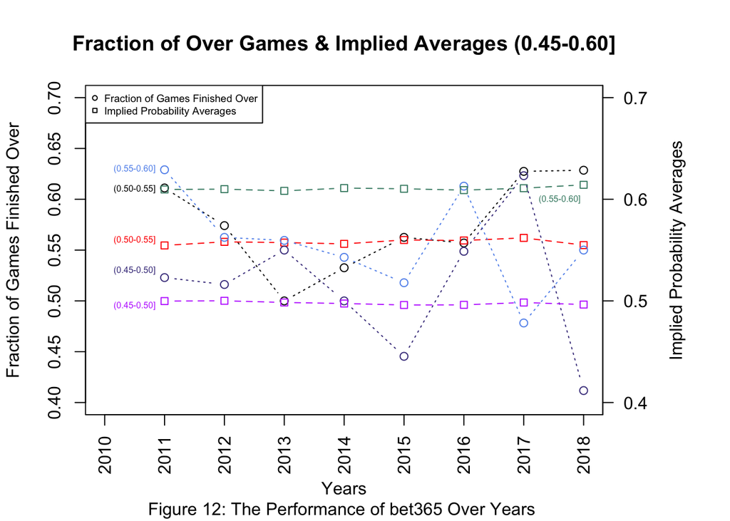

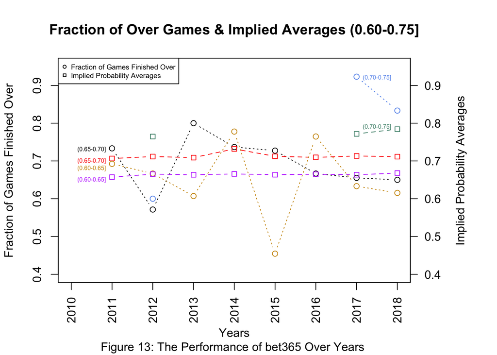

In this plot, there are bins within 0.60-0.75 range. In (0.60-0.65] bin, the performance is good in years from 2011 to 2013. Then, it gets worse for 2 years, and it improves again. In (0.65-0.70] bin, except 2012 and 2013, the performance is consistently good. In (0.70-0.75] bin, there are only observations from 2012, 2017 and 2018. Hence, when 2017 and 2018 are compared, the performance improved in 2018.

In conclusion, it cannot be said that the performance of bet365 is consistently good at determining the “over” probabilities since there are some fluctuations among the years.

## Task 2

The objective in this task is to capture the information that may come from the change in the odds for match results. The scatterplots from the lattice package can be helpful in this study since it also allows categorical variable (odd types in this scenario) breakdowns easily.

First, the subset of the matches that have match result odd information is chosen. The bookmaker having the highest number of odd information is “Betclic”, and the analysis is going to be continued based on the odds from “Betclic”.

```r
library(lattice)
library(gridExtra)  #the necessary libraries for this task
data_result <- data_odds[betType == "1x2"]
bookmakers <- data_result[, .N, keyby = .(bookmaker)]
bookmakers <- bookmakers[order(-N)]
betclic <- data_result[bookmaker == "Betclic"]
```

Betclic has odds information for 3084 matches in total where the odd changes can be analyzed for match results. However, for simplicity, 4 of them will be selected randomly and analyzed in terms of odd changes.

```r
matches <- betclic[, .N, keyby = .(matchId)]
matches <- matches[order(-N)]
# random match ID's
match1 <- betclic[matchId == matches[208, 1]]  #score:(1:0)
match2 <- betclic[matchId == matches[229, 1]]  #score:(2:0)
match3 <- betclic[matchId == matches[273, 1]]  #score:(1:2)
match4 <- betclic[matchId == matches[257, 1]]  #score:(2:2)
```

In the plots, the x axis will show the time information starting with the time of the first odds for that particular match and ending with the time of the last odds. On the other hand, the y axis has odd information. The breakdown is based on the oddtypes; so that the changes in the home-win, tie and away-win odds can be analyzed seperately since they can provide different information. The plots are given below:

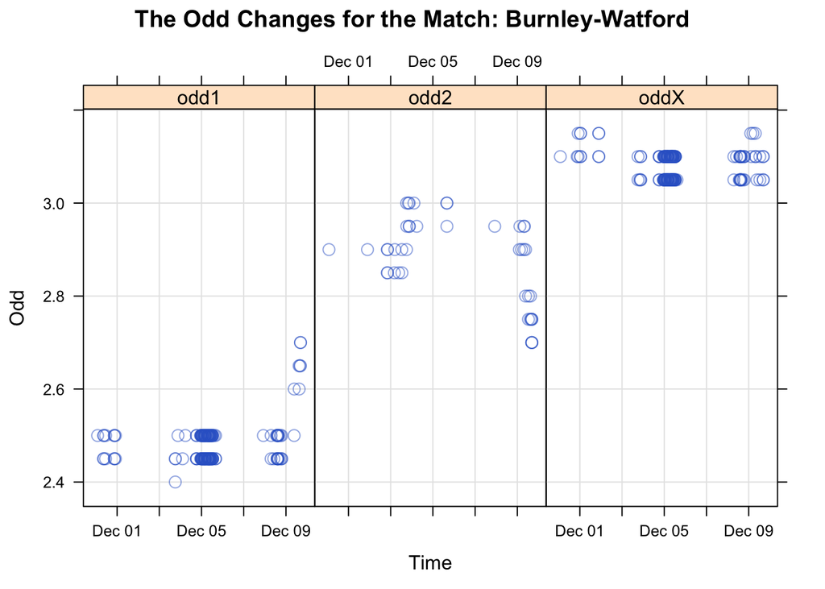

```r
plot1 <- xyplot(odd ~ as.POSIXct(date, origin = "1970-01-01") |
    oddtype, data = match1, main = "The Odd Changes for the Match: Burnley-Watford",
    xlab = "Time", ylab = "Odd", grid = TRUE, pch = 1, cex = 1.2,
    col = rgb(0.2, 0.4, 0.8, 0.5))
plot2 <- xyplot(odd ~ as.POSIXct(date, origin = "1970-01-01") |
    oddtype, data = match2, main = "The Odd Changes for the Match: Everton-Huddersfield",
    xlab = "Time", ylab = "Odd", grid = TRUE, pch = 1, cex = 1.2,
    col = rgb(0.2, 0.4, 0.8, 0.5))
plot3 <- xyplot(odd ~ as.POSIXct(date, origin = "1970-01-01") |
    oddtype, data = match3, main = "The Odd Changes for the Match: Watford-Manchester United",
    xlab = "Time", ylab = "Odd", grid = TRUE, pch = 1, cex = 1.2,
    col = rgb(0.2, 0.4, 0.8, 0.5))
plot4 <- xyplot(odd ~ as.POSIXct(date, origin = "1970-01-01") |
    oddtype, data = match4, main = "The Odd Changes for the Match: West Brom-Newcastle United",
    xlab = "Time", ylab = "Odd", grid = TRUE, pch = 1, cex = 1.2,
    col = rgb(0.2, 0.4, 0.8, 0.5))
# grid.arrange(plot1,plot2,plot3,plot4, ncol=2)
plot1
```

Here it can be seen that at first, the first team was thought to be more likely to win the match, so that home-win odds is less. However, as the time passed, the bookmaker increased the odds for home-win and therefore decreased the odds for away-win which may be due to an injury in the home team or etc. In the time between, the odds fluctuated slightly. In the end, it seems that two are equally likely to win the match. The score of the match is 1-0, so the bookmaker should not have increased the odds for home-win.

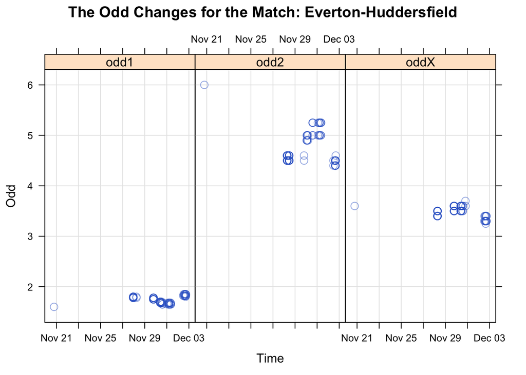

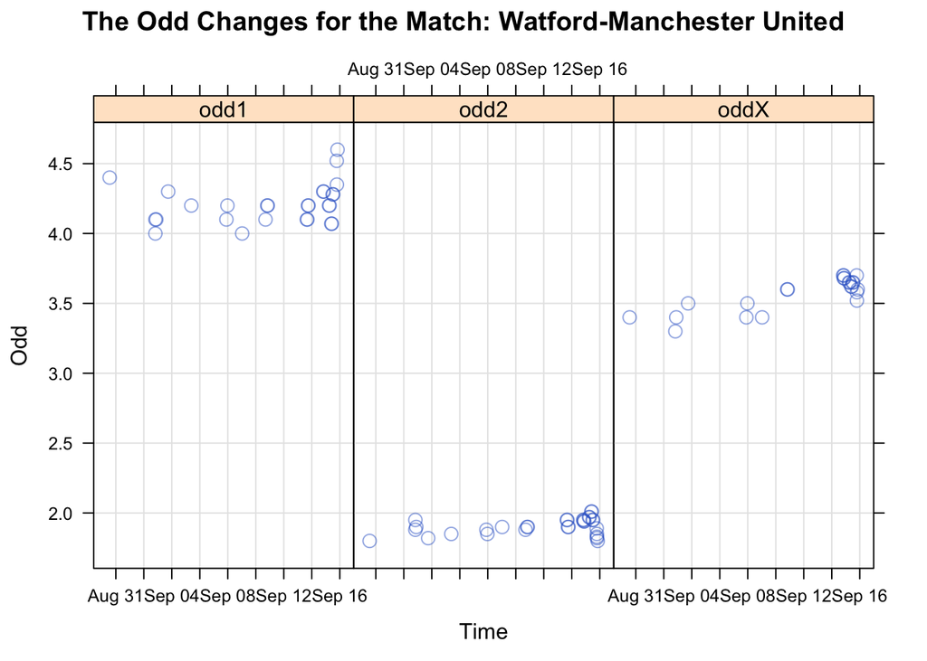

From this plot, it can be seen that in 2-week period, the odds continuously changed. For this match, the away-team was favourite, and juft before the match the odds for away-win decreased even more. It may be due to any unexpected condition again for the home-team. The bookmaker did well on setting the odds for this match because the score was 1-2.

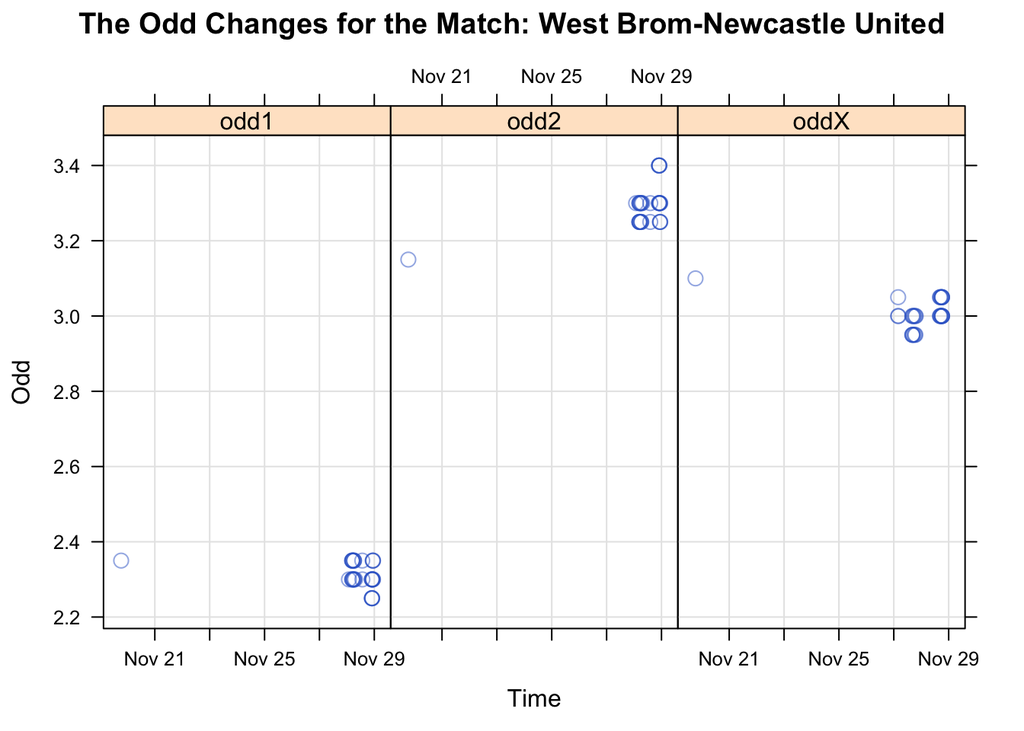

From the last plot, it can be seen that in 10-day period before the match, the conditions did not change so much that odds remained constant. However, in the last days, some small fluctuations happened, but the home-team remained the favourite. As it can be observed, the difference in the odds of home-win and away-win is not as much as the second match above which means the difference in the likelihood of one team winning is not too much, and the match ended as 2-2.

In order to analyze the odd changes, I chose this type of plot where each match can be observed seperately since each match has unique set of conditions such as team players, injuries, red cards etc. There may be for sure other ways to explore the changes in the odds.